# STRAITS Annual tagging report

Claudia Meneses

11/10/2023

## The STRAITS project

Strategic Infrastructure for improved animal Tracking in European Seas (STRAITS) will leverage ongoing acoustic tracking projects across the four corners of Europe (i.e., North Channel, Danish Straits, Straits of Gibraltar and the Bosporus/Dardanelles) by expanding efforts to connect initiatives on species-based biodiversity management while developing data management plans and networking channels to deliver data to national and international governing bodies.

Coordinating aquatic animal tracking and environmental observation efforts at a scale that will be usable to make progress on international marine management and planning, is a major step towards an operational European Tracking Network (ETN) that contributes to major European biodiversity initiatives, conservation, and policy.

## Tagging efforts Pieterjan Verhalst PhD (2015)

### Overview

Overview table of the tagging effort

| scientific_name | tag_type | year | capture_location | capture_method | n |
| --- | --- | --- | --- | --- | --- |
| Anguilla anguilla | acoustic | 2015 | Dijle (weir Mechelen Nekkerspoel) | double fyke nets | 9 |
| Anguilla anguilla | acoustic | 2015 | Zeeschelde (Bergenmeersen, Wichelen) | double fyke nets | 4 |
| Anguilla anguilla | acoustic | 2015 | Zeeschelde (Killeweg, Dendermonde) | double fyke nets | 2 |
| Anguilla anguilla | acoustic | 2015 | Zeeschelde (Lepelstraat, Rupelmonde) | double fyke nets | 2 |
| Anguilla anguilla | acoustic | 2015 | Zeeschelde (ringvaart, Merelbeke) | double fyke nets | 20 |
| Anguilla anguilla | acoustic | 2015 | Zeeschelde (veerboot, Kastel) | double fyke nets | 7 |
| Gadus morhua | acoustic | 2015 | Appelzak Westerschelde | line fishing | 1 |
| Gadus morhua | acoustic | 2015 | C05 Belwind | line fishing | 10 |
| Gadus morhua | acoustic | 2015 | Kilmore | line fishing | 5 |
| Gadus morhua | acoustic | 2015 | Paardemarkt | line fishing | 6 |
| Gadus morhua | acoustic | 2015 | Reefballs C-Power | line fishing | 8 |
| Gadus morhua | acoustic | 2015 | Spijkerplaat (thv Stella) | line fishing | 12 |

### Tagging effort year 2015

Number of individuals tagged per species in 2015

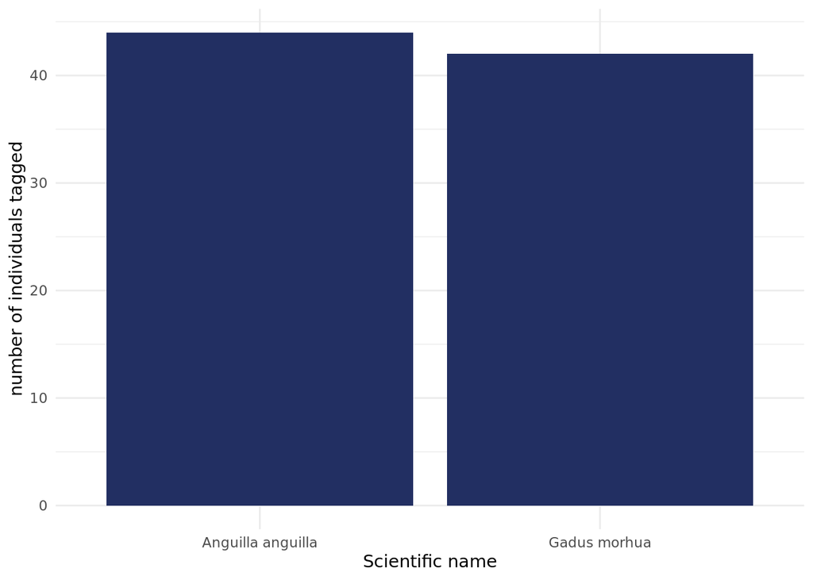

### Mortality ?

Mortality is not tracked in ETN, as in, only alive individuals are uploaded to the system. This would be the only parameter that can not be added with ETN info alone.

### Biometrics?

Not sure if that term can only be used for humans.

#### Females vs males

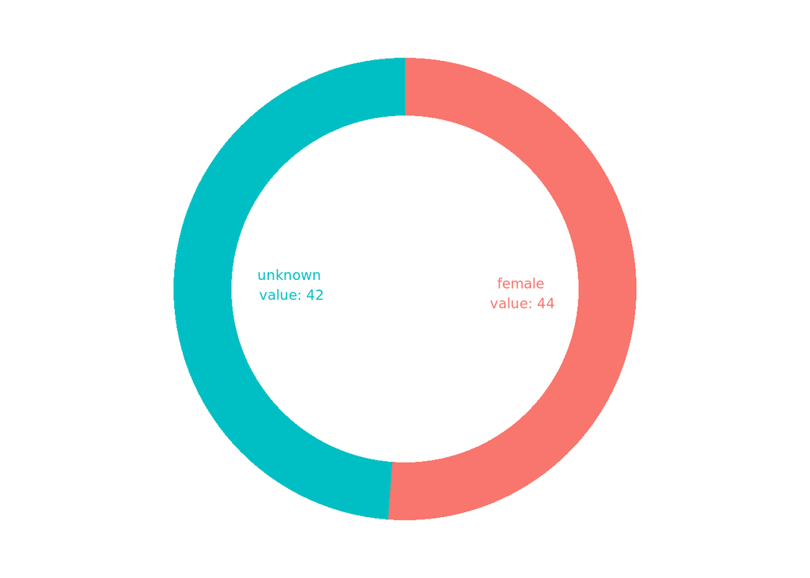

#### Other

Other biometrics. There is a full list of options to chose from the ETN animals metadata template.

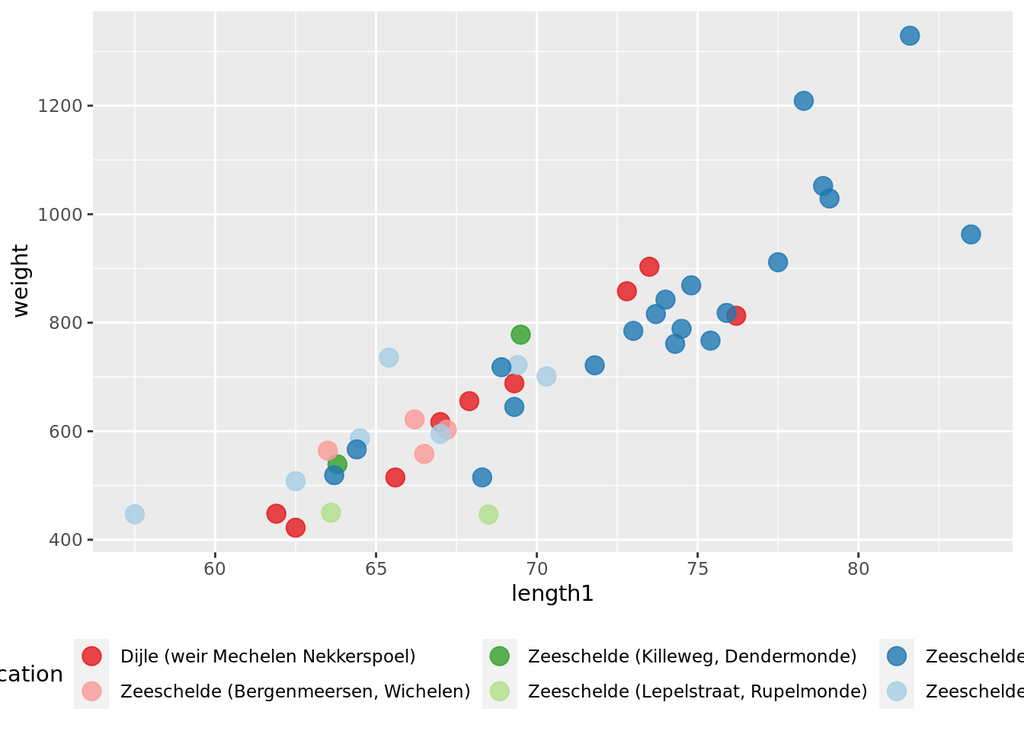

### Tagging location

[interactive chart not shown]